# Specifiyng weights in Log-rank comparisons

Marcin Kosinski

29-01-2017

```r
library("survminer")
```

> This vignette covers changes between versions 0.2.4 and 0.2.5 for specifiyng weights in the log-rank comparisons done in `ggsurvplot()`.

# Log-rank statistic for 2 groups

As it is stated in the literature, the Log-rank test for comparing survival (estimates of survival curves) in 2 groups ($A$ and $B$) is based on the below statistic

$$LR = \frac{U^2}{V} \sim \chi(1),$$

where
$$U = \sum_{i=1}^{T}w_{t_i}(o_{t_i}^A-e_{t_i}^A), \ \ \ \ \ \ \ \ V = Var(U) = \sum_{i=1}^{T}(w_{t_i}^2\frac{n_{t_i}^An_{t_i}^Bd_i(n_{t_i}-o_{t_i})}{n_{t_i}^2(n_{t_i}-1)})$$
and

- $t_i$ for $i=1, \dots, T$ are possible event times,
- $n_{t_i}$ is the overall risk set size on the time $t_i$ ($n_{t_i} = n_{t_i}^A+n_{t_i}^B$),
- $n_{t_i}^A$ is the risk set size on the time $t_i$ in group $A$,
- $n_{t_i}^B$ is the risk set size on the time $t_i$ in group $B$,
- $o_{t_i}$ overall observed events in the time $t_i$ ($o_{t_i} = o_{t_i}^A+o_{t_i}^B$),
- $o_{t_i}^A$ observed events in the time $t_i$ in group $A$,
- $o_{t_i}^B$ observed events in the time $t_i$ in group $B$,
- $e_{t_i}$ number of overall expected events in the time $t_i$ ($e_{t_i} = e_{t_i}^A+e_{t_i}^B$),
- $e_{t_i}^A$ number of expected events in the time $t_i$ in group $A$,
- $e_{t_i}^B$ number of expected events in the time $t_i$ in group $B$,
- $w_{t_i}$ is a weight for the statistic,

also remember about few notes

$$e_{t_i}^A = n_{t_i}^A \frac{o_{t_i}}{n_{t_i}}, \ \ \ \ \ \ \ \ \ \ e_{t_i}^B = n_{t_i}^B \frac{o_{t_i}}{n_{t_i}},$$
$$e_{t_i}^A + e_{t_i}^B = o_{t_i}^A + o_{t_i}^B$$

that’s why we can substitute group $A$ with $B$ in $U$ and receive same results.

# Weighted Log-rank extensions

Regular Log-rank comparison uses $w_{t_i} = 1$ but many modifications to that approach have been proposed. The most popular modifications, called weighted Log-rank tests, are available in `?survMisc::comp`

- `n` Gehan and Breslow proposed to use $w_{t_i} = n_{t_i}$ (this is also called generalized Wilcoxon),
- `srqtN` Tharone and Ware proposed to use $w_{t_i} = \sqrt{n_{t_i}}$,
- `S1` Peto-Peto’s modified survival estimate $w_{t_i} = S1({t_i}) = \prod_{i=1}^{T}(\frac{1-e_{t_i}}{n_{t_i}+1})$,
- `S2` modified Peto-Peto (by Andersen) $w_{t_i} = S2({t_i}) = \frac{S1({t_i})n_{t_i}}{n_{t_i}+1}$,
- `FH` Fleming-Harrington $w_{t_i} = S(t_i)^p(1 - S(t_i))^q$.

> Watch out for `FH` as I [submitted an info on survMisc repository](https://github.com/dardisco/survMisc/issues/15) where I think their mathematical notation is misleading for Fleming-Harrington.

## Why are they useful?

The regular Log-rank test is sensitive to detect differences in late survival times, where Gehan-Breslow and Tharone-Ware propositions might be used if one is interested in early differences in survival times. Peto-Peto modifications are also useful in early differences and are more robust (than Tharone-Whare or Gehan-Breslow) for situations where many observations are censored. The most flexible is Fleming-Harrington method for weights, where high `p` indicates detecting early differences and high `q` indicates detecting differences in late survival times. But there is always an issue on how to detect `p` and `q`.

> Remember that test selection should be performed at the research design level! Not after looking in the dataset.

# Plots

```r
library("survival")
data("lung")
fit <- survfit(Surv(time, status) ~ sex, data = lung)
```

After preparing a functionality for this GitHub’s issue [Other tests than log-rank for testing survival curves and Log-rank test for trend](https://github.com/kassambara/survminer/issues/17) we are now able to compute p-values for various Log-rank test in survminer package. Let as see below examples on executing all possible tests.

## Log-rank (survdiff)

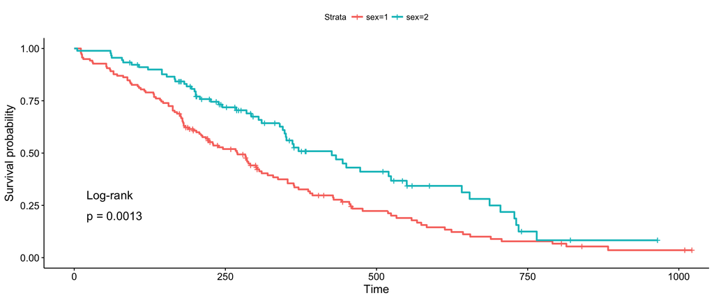

```r
ggsurvplot(fit, data = lung, pval = TRUE, pval.method = TRUE)
```

## Log-rank (comp)

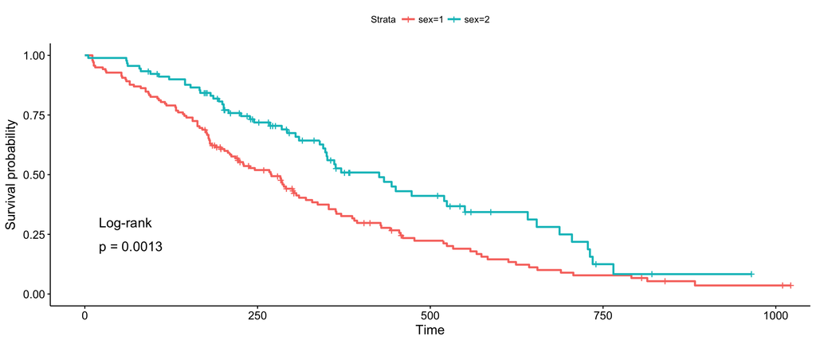

```r
ggsurvplot(fit, data = lung, pval = TRUE, pval.method = TRUE,
           log.rank.weights = "1")
```

## Gehan-Breslow (generalized Wilcoxon)

[figure not shown]

```r
ggsurvplot(fit, data = lung, pval = TRUE, pval.method = TRUE,
           log.rank.weights = "n", pval.method.coord = c(5, 0.1),
           pval.method.size = 3)
```

## Tharone-Ware

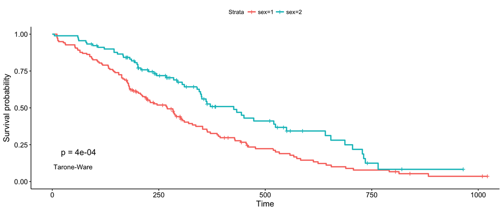

```r
ggsurvplot(fit, data = lung, pval = TRUE, pval.method = TRUE,
           log.rank.weights = "sqrtN", pval.method.coord = c(3, 0.1),
           pval.method.size = 4)
```

## Peto-Peto’s modified survival estimate

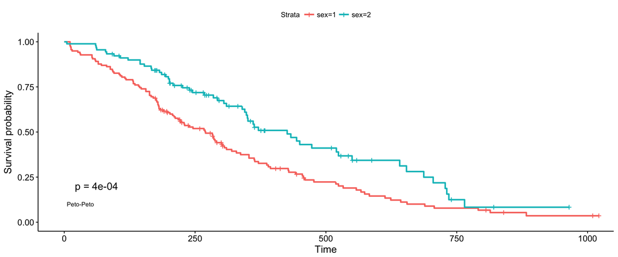

```r
ggsurvplot(fit, data = lung, pval = TRUE, pval.method = TRUE,
           log.rank.weights = "S1", pval.method.coord = c(5, 0.1),
           pval.method.size = 3)
```

## modified Peto-Peto’s (by Andersen)

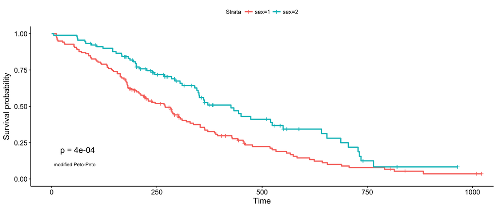

```r
ggsurvplot(fit, data = lung, pval = TRUE, pval.method = TRUE,
           log.rank.weights = "S2", pval.method.coord = c(5, 0.1),
           pval.method.size = 3)
```

## Fleming-Harrington (p=1, q=1)

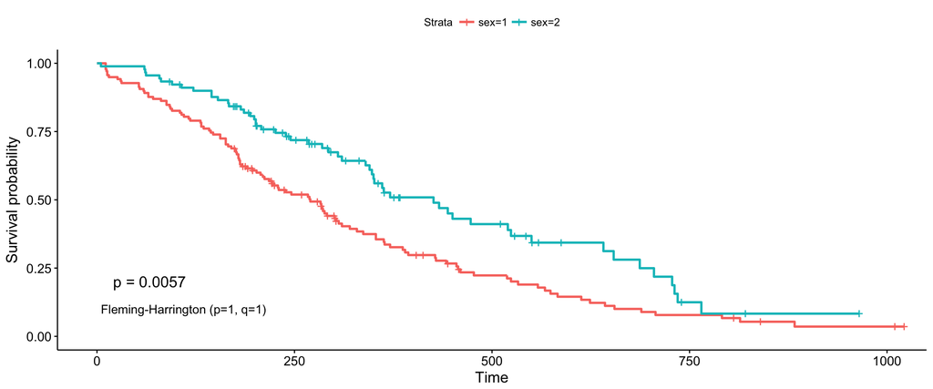

```r
ggsurvplot(fit, data = lung, pval = TRUE, pval.method = TRUE,
           log.rank.weights = "FH_p=1_q=1",
           pval.method.coord = c(5, 0.1),
           pval.method.size = 4)
```

# References

- Gehan A. A Generalized Wilcoxon Test for Comparing Arbitrarily Singly-Censored Samples. Biometrika 1965 Jun. 52(1/2):203-23. JSTOR
- Tarone RE, Ware J 1977 On Distribution-Free Tests for Equality of Survival Distributions. Biometrika;64(1):156-60. [JSTOR](http://www.jstor.org/stable/2335790)
- Peto R, Peto J 1972 Asymptotically Efficient Rank Invariant Test Procedures. J Royal Statistical Society 135(2):186-207. [JSTOR](http://www.jstor.org/stable/2344317)
- Fleming TR, Harrington DP, O’Sullivan M 1987 Supremum Versions of the Log-Rank and Generalized Wilcoxon Statistics. J American Statistical Association 82(397):312-20. [JSTOR](http://www.jstor.org/stable/2289169)
- Billingsly P 1999 Convergence of Probability Measures. New York: John Wiley & Sons. Wiley (paywall)